# Explore mitochondrial gene effect on UMAP plots

S. Spielman for CCDL

2023

This notebook aims to explore some potential sequencing center biases that were raised in this OpenPBTA issue: https://github.com/AlexsLemonade/OpenPBTA-analysis/issues/1601 This issues notes that some of the samples sequenced at `BGI@CHOP` had higher-than-expected expression for certain mitochondrial genes, specifically RNR1 and RNR2, and somewhat lower-than-expected expression for other mitochondrial genes.

To ensure appropriate normalization, the UMAPs here were created from TPM data rather than FPKM, such that mitochondrial genes were removed from the TPM results themselves.

## Setup

Define directories and file names:

```r
# Directories
root_dir <- rprojroot::find_root(rprojroot::has_dir(".git"))
data_dir <- file.path(root_dir, "data")
tumor_dir <- file.path(root_dir, "analyses", "tumor-purity-exploration")
umap_dir <- file.path(
  root_dir,
  "analyses",
  "transcriptomic-dimension-reduction",
  "results"
)
palette_dir <- file.path(root_dir, "figures", "palettes")

# UMAP files with different samples:
tpm_umap <- file.path(umap_dir, "tpm_stranded_all_log_umap_scores_aligned.tsv")
tpm_no_mito_umap <- file.path(umap_dir, "tpm_stranded_nomito_log_umap_scores_aligned.tsv")

# palette mapping file
pal_file <- file.path(palette_dir,  "broad_histology_cancer_group_palette.tsv")

# FPKM
expression_file <- file.path(data_dir, "pbta-gene-expression-rsem-fpkm-collapsed.stranded.rds")

metadata_file <- file.path(data_dir, "pbta-histologies.tsv")
```

```r
# Read in palette data
palette_mapping_df <- readr::read_tsv(pal_file) %>%
  dplyr::select(broad_histology, broad_histology_display, broad_histology_hex,
                cancer_group, cancer_group_display, cancer_group_hex)
# Read in and prep UMAP data
# helper function
readr_prep_umap <- function(filename,
                            pal_df = palette_mapping_df) {
  readr::read_tsv(filename) %>%
    dplyr::rename(UMAP1 = X1, UMAP2 = X2) %>%
    dplyr::inner_join(pal_df) %>%
    dplyr::mutate(seq_center = forcats::fct_relevel(seq_center,
                                                    "BGI", "BGI@CHOP Genome Center", "NantOmics"))
}

umap_all <- readr_prep_umap(tpm_umap)
umap_no_mito <- readr_prep_umap(tpm_no_mito_umap)
# Read in expression and convert to data frame
expression_df <- readr::read_rds(expression_file) %>%
  tibble::as_tibble(rownames = "gene_symbol")

# Read in metadata
metadata_df <- readr::read_tsv(metadata_file)
```

## Explore mitochondrial genes

For mitochondrial genes, do we see expression patterns for BGI@CHOP samples consistent with those posted in the issue linked above?

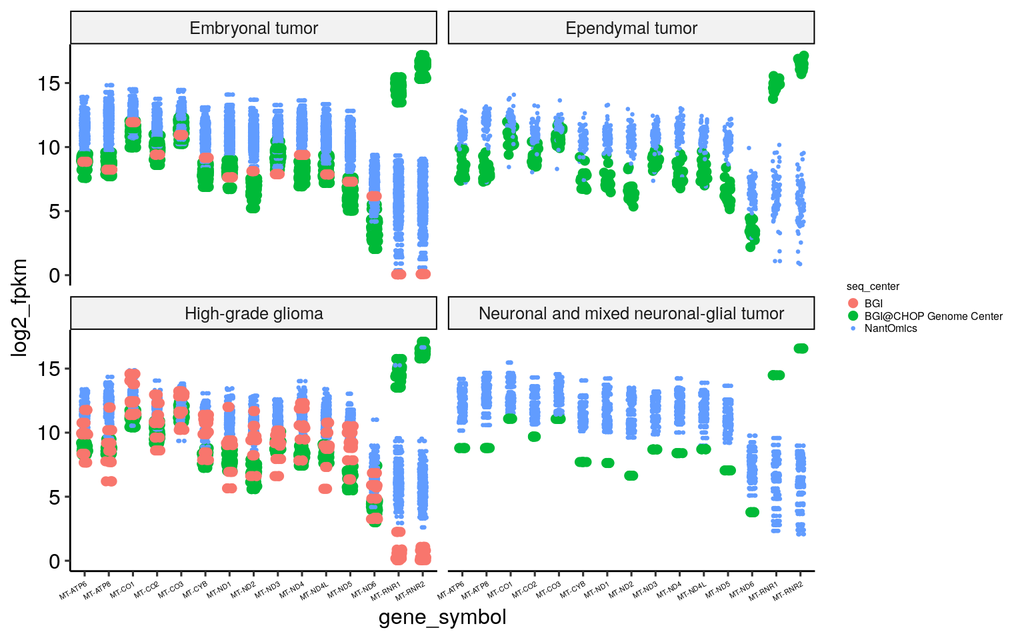

```r
# First, which diagnoses are sequenced at BGI@CHOP?
relevant_groups <- metadata_df %>%
  dplyr::filter(RNA_library == "stranded",
                stringr::str_starts(seq_center, "BGI")) %>%
  tidyr::drop_na(broad_histology) %>%
  dplyr::pull(broad_histology) %>%
  unique()

# Data frame of log2(FPKM) of mitochondrial genes for relevant diagnoses
mito_seq_center_df <- expression_df %>%
  dplyr::filter(stringr::str_starts(gene_symbol, "MT-")) %>%
  tidyr::gather("Kids_First_Biospecimen_ID",
                "fpkm",
                tidyselect::starts_with("BS_")) %>%
  dplyr::mutate(log2_fpkm = log2(fpkm+1)) %>%
  # get diagnoses across samples
  dplyr::inner_join(
    dplyr::select(metadata_df,
                  Kids_First_Biospecimen_ID,
                  broad_histology,
                  seq_center)
  ) %>%
  # filter to only relevant groups
  dplyr::filter(broad_histology %in% relevant_groups) %>%
  # get display version of diagnosis
  dplyr::inner_join(
    dplyr::select(palette_mapping_df,
                  broad_histology,
                  broad_histology_display)
  )
ggplot(mito_seq_center_df) +
  aes(x = gene_symbol, y = log2_fpkm, color = seq_center, size = seq_center) +
  geom_jitter(width = 0.15) +
  # emphasize the BGI points!
  scale_size_manual(values = c(2, 2, 0.5)) +
  facet_wrap(~broad_histology_display) +
  theme(axis.text.x = element_text(angle = 30, hjust = 1, size = 4))
```

Thus, `BIG@CHOP` (not `BGI`) samples are the main “concern” here.

## UMAP

How do UMAPs with and without mitochondrial genes compare? We might expect particular changes in embryonal, ependymal, and HGG since BGI is mostly those dianogses.

```r
# Function to plot UMAP and set up color palettes.
plot_umap <- function(df, color_group, color_palette, title) {
  ggplot(df) +
    aes(x = UMAP1, y = UMAP2,
      shape = seq_center,
      fill = {{color_group}},
      color = seq_center,
      alpha = seq_center) +
  geom_point(size = 2.5) +
  scale_shape_manual(values = c(22, 24, 21)) +
  scale_fill_manual(values  = color_palette,
                    # This "shape" override is needed for legend fill colors to actually work
                    guide = guide_legend(override.aes = list(shape = 21, size = 2))) +
  scale_color_manual(values = c("grey70", "black", "black"),
                     # These overrides ensure shapes appear all in same alpha/color in legend
                     guide = guide_legend(override.aes = list(color = "black", alpha = 1, size = 2))) +
  scale_alpha_manual(values = c(0.3, 0.5, 0.5)) +
  ggtitle(title) +
  # tweaks for legibility
  theme(legend.position = "bottom",
        legend.text = element_text(size = rel(0.5)),
        legend.title = element_text(size = rel(0.5)),
        legend.key.size = unit(0.25, "cm")
  )
}

# Another plotting helper function to cowplot some plots with a shared legend
combine_plots <- function(p1, p2) {
  p_legend <- cowplot::get_legend(p1)

  plot_row <- cowplot::plot_grid(p1 + theme(legend.position = "none"),
                                 p2 + theme(legend.position = "none"),
                                 nrow = 1,
                                 rel_widths = 0.95)

  full_grid <- cowplot::plot_grid(plot_row, p_legend, nrow = 2, rel_heights = c(1, 0.2))

  full_grid
}


# set up color palettes
bh_df <- palette_mapping_df %>%
  dplyr::select(broad_histology_display, broad_histology_hex) %>%
  dplyr::distinct()
pal_bh<- bh_df$broad_histology_hex
names(pal_bh) <- bh_df$broad_histology_display

cg_df <- palette_mapping_df %>%
  dplyr::select(cancer_group_display, cancer_group_hex) %>%
  dplyr::distinct() %>%
  tidyr::drop_na()
pal_cg<- cg_df$cancer_group_hex
names(pal_cg) <- cg_df$cancer_group_display
```

Let’s plot some UMAPs!

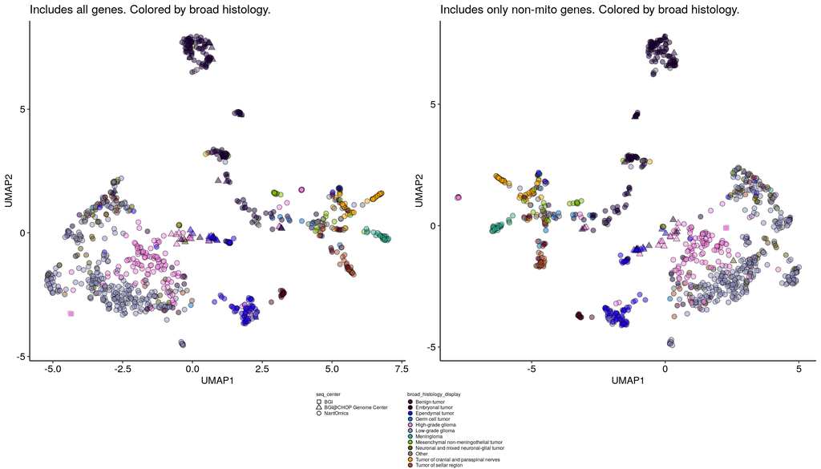

```r
p1 <- plot_umap(umap_all, broad_histology_display, pal_bh, "Includes all genes. Colored by broad histology.")
p2 <- plot_umap(umap_no_mito, broad_histology_display, pal_bh, "Includes only non-mito genes. Colored by broad histology.")
combine_plots(p1, p2)
```

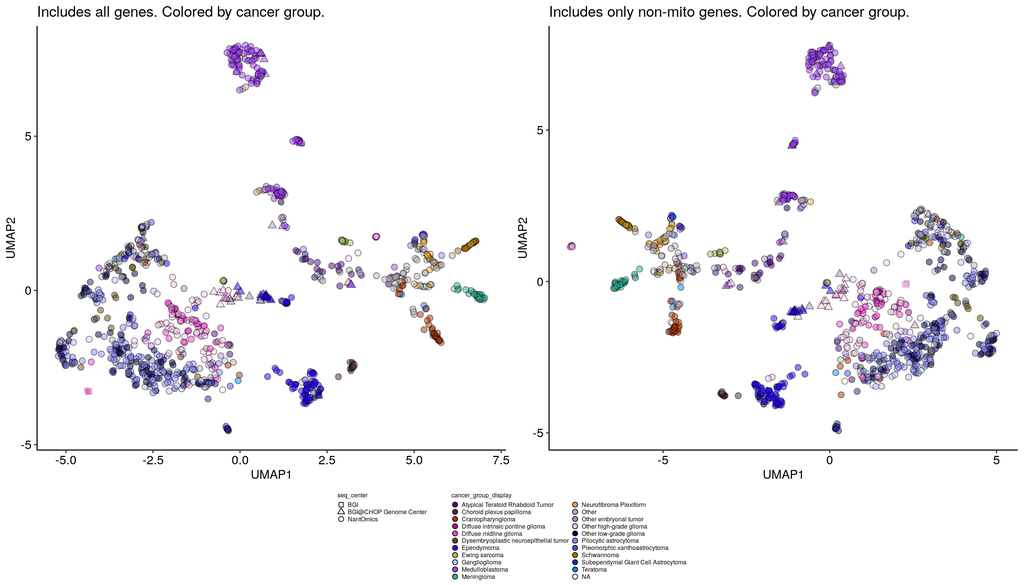

```r
p1 <- plot_umap(umap_all, cancer_group_display, pal_cg, "Includes all genes. Colored by cancer group.")
p2 <- plot_umap(umap_no_mito, cancer_group_display, pal_cg, "Includes only non-mito genes. Colored by cancer group.")
combine_plots(p1, p2)
```

## Conclusions

- Samples from `BIG@CHOP` sequencing center have unique mitochondrial gene distributions.
- Removing mitochondrial genes from the UMAP does not have a strong qualitiative effect on whether broad histologies or cancer groups tend to cluster together. The UMAPs created here also look broadly similar to those made with FPKM. Visually, it seems the “mixed histology” groupings identified in `04-explore-sequencing-center-effects.Rmd` notebook still are grouped together in these UMAPs.

Overall, this suggests that mitochondrial genes alone will not have a strong influence on UMAP visualizations. However, there may still be protocol differences associated with BIG@CHOP samples that influence expression values more generally, and can not be corrected by removing only mitochondrial genes.